# re_ml_02

David Fäh 23-106-396

2025-04-29

## Introduction

```r
# load libraries
library(dplyr)
library(ggplot2)
library(readr)
library(tidyr)
library(caret)
library(recipes)
library(here)
library(cowplot)

# load data
laegern_fluxes <- read_csv(here::here("data/FLX_CH-Lae_FLUXNET2015_FULLSET_DD_2004-2014_1-4.csv"))
davos_fluxes <- read_csv(here::here("data/FLX_CH-Dav_FLUXNET2015_FULLSET_DD_1997-2014_1-3.csv"))



# create function to clean data
clean_flux_data <- function(data){

  # select only the variables we are interested in
  data |> dplyr::select(TIMESTAMP,
                        GPP_NT_VUT_REF,    # the target
                        ends_with("_QC"),  # quality control info
                        ends_with("_F"),   # includes all all meteorological covariates
                        -contains("JSB")   # weird useless variable
                        ) |>

    # convert to a nice date object
    dplyr::mutate(TIMESTAMP = lubridate::ymd(TIMESTAMP)) |>

    # set all -9999 to NA
    mutate(across(where(is.numeric), ~na_if(., -9999))) |>

    # retain only data based on >=80% good-quality measurements
    # overwrite bad data with NA (not dropping rows)
    dplyr::mutate(GPP_NT_VUT_REF = ifelse(NEE_VUT_REF_QC < 0.8, NA, GPP_NT_VUT_REF),
                  TA_F           = ifelse(TA_F_QC        < 0.8, NA, TA_F),
                  SW_IN_F        = ifelse(SW_IN_F_QC     < 0.8, NA, SW_IN_F),
                  LW_IN_F        = ifelse(LW_IN_F_QC     < 0.8, NA, LW_IN_F),
                  VPD_F          = ifelse(VPD_F_QC       < 0.8, NA, VPD_F),
                  PA_F           = ifelse(PA_F_QC        < 0.8, NA, PA_F),
                  P_F            = ifelse(P_F_QC         < 0.8, NA, P_F),
                  WS_F           = ifelse(WS_F_QC        < 0.8, NA, WS_F)) |>

    # drop QC variables (no longer needed)
    dplyr::select(-ends_with("_QC")) |>
    dplyr::select(-P_F) # drop P_F because for Laegern, the whole column is NA
}



# clean data
davos_fluxes <- clean_flux_data(davos_fluxes)
laegern_fluxes <- clean_flux_data(laegern_fluxes)
```

## Modeling

```r
# set seed
set.seed(1984)

# define function to split data
split_data <- function(data){
  split <- rsample::initial_split(data, prop = 0.8, strata = "VPD_F")
  list(
    train = rsample::training(split),
    test = rsample::testing(split))
}

# split data from davos and laegern sites
davos_split <- split_data(davos_fluxes)
laegern_split <- split_data(laegern_fluxes)

# define a combined data set for train and test data
combined_split <- list(
  train = bind_rows(davos_split$train, laegern_split$train),
  test = bind_rows(davos_split$test, laegern_split$test))


# define function to create a recipe
create_recipe <- function(data){
  # Model and pre-processing formulation, use all variables but LW_IN_F
  recipes::recipe(GPP_NT_VUT_REF ~ SW_IN_F + VPD_F + TA_F,
                  data = data |> drop_na()) |>
  step_center(all_numeric(), -all_outcomes()) |>
  step_scale(all_numeric(), -all_outcomes())
}

# create recipes
davos_recipe <- create_recipe(davos_split$train)
laegern_recipe <- create_recipe(laegern_split$train)
combined_recipe <- create_recipe(combined_split$train)


# define function to fit KNN model
# use cross validation and hyperparameter tuning for optimal results
fit_knn_model <- function(train_data, recipe){
  caret::train(
  recipe,
  data = train_data |> drop_na(),
  method = "knn",
  trControl = caret::trainControl(method = "cv", number = 10),
  tuneGrid = data.frame(k = seq(1, 50)),
  metric = "RMSE"
 )
}

# fit model
davos_only_model <- fit_knn_model(davos_split$train, davos_recipe)
laegern_only_model <- fit_knn_model(laegern_split$train, laegern_recipe)
combined_model <- fit_knn_model(combined_split$train, combined_recipe)



# define function to test the model and extract metrics
test_model <- function(model, test_data){

  # drop NA from test data
  test_data <- test_data |> drop_na()

  # define predictions and observations
  predictions <- predict(model, newdata = test_data)
  observations <- test_data$GPP_NT_VUT_REF

  # calculate metrics
  r2 <- cor(observations, predictions)^2
  rmse <- sqrt(mean((observations - predictions)^2))

  return(c(R2 = r2, RMSE = rmse))
}
```

## Evaluate models

```r
davos_evaluation <- bind_rows(
  "Evaluation against Davos test set: " = test_model(davos_only_model, davos_split$test),
  "Evaluation against Laegern test set: " = test_model(davos_only_model, laegern_split$test),
  "Evaluation against combined test set: " = test_model(davos_only_model, combined_split$test),
  .id = "Model trained on data from Davos"
)

laegern_evaluation <- bind_rows(
  "Evaluation against Davos test set: " = test_model(laegern_only_model, davos_split$test),
  "Evaluation against Laegern test set: " = test_model(laegern_only_model, laegern_split$test),
  "Evaluation against combined test set: " = test_model(laegern_only_model, combined_split$test),
  .id = "Model trained on data from Laegern"
)

combined_evaluation <- bind_rows(
  "Evaluation against Davos test set: " = test_model(combined_model, davos_split$test),
  "Evaluation against Laegern test set: " = test_model(combined_model, laegern_split$test),
  "Evaluation against combined test set: " = test_model(combined_model, combined_split$test),
  .id = "Model trained on data from Laegern and Davos"
)
```

**Present Results**

```r
knitr::kable(davos_evaluation)
```

| Model trained on data from Davos | R2 | RMSE |
| --- | --- | --- |
| Evaluation against Davos test set: | 0.6378665 | 1.514180 |
| Evaluation against Laegern test set: | 0.5022381 | 3.395701 |
| Evaluation against combined test set: | 0.5148298 | 2.719189 |

```r
knitr::kable(laegern_evaluation)
```

| Model trained on data from Laegern | R2 | RMSE |
| --- | --- | --- |
| Evaluation against Davos test set: | 0.4918824 | 2.549884 |
| Evaluation against Laegern test set: | 0.6654120 | 2.471060 |
| Evaluation against combined test set: | 0.5843495 | 2.506664 |

```r
knitr::kable(combined_evaluation)
```

| Model trained on data from Laegern and Davos | R2 | RMSE |
| --- | --- | --- |
| Evaluation against Davos test set: | 0.5855091 | 1.825779 |
| Evaluation against Laegern test set: | 0.6455072 | 2.610546 |
| Evaluation against combined test set: | 0.6172967 | 2.292584 |

## Interpretation

**What are the patterns that you see in the tables?**

- Each model performs best when evaluated on test data from the same site that it was trained on. This makes sense because the sites differ in environmental conditions and the model is “used to” the environment of the respective site.
- The combined model is the second best on Davos data and Laegern data. This also makes sense because it captures more environmental variability. It is trained with a “mix” of both environments, leading to more accurate predictions on new sites than if a model is trained with data from a completely different environment. But its performance is not as strong as that of a model trained exclusively on the test site.
- The combined model has the best over-all performance (highest generalisability).

**How well do models trained on one site perform on another site? Why is this the case?**

- The models that were trained only with data from one site perform best on this respective site.
- On other sites, they perform much worse because the KNN model was trained with data from another location. The sites differ in environmental conditions such as altitude, temperature and length of growing season.
  - Davos:
    - Elevation: 1639m (in the alps)
    - Mean Annual Temperature: 2.8 °C
    - Dominant vegetation: Evergreen needle leaf forests
    - Vegetation growing season: 100 - 120 days
  - Laegern:
    - Elevation: 689m (before the alpine ridge)
    - Mean Annual Temperature: 8.3 °C
    - Dominant vegetation: mixed forests
    - Vegetation growing season: 180 - 210 days
- Example: The model trained on Davos data looks for similar neighbors when applied to the Laegern data. But the data follows different patterns and therefore the neighbors are not as powerful to make predictions.

### Validation of my interpretation

To test this, I apply the Davos-trained model to Laegern data and vice versa. My hypothesis is that the Davos-trained model will predict a GPP for Laegern that is too low compared to the observations. The Laegern-trained model on the other hand will predict a GPP for Davos that is too high compared to the observations.

```r
# define function to get model predictions vs. observations along a time-series
get_model_predictions <- function(model, test_data){

  # drop NA from test data
  test_data <- test_data |> drop_na()

  # define predictions and observations
  predictions <- predict(model, newdata = test_data)
  observations <- test_data$GPP_NT_VUT_REF

  return(data.frame(
    Predictions = predictions,
    Observations = observations,
    Date = test_data$TIMESTAMP))
}
```

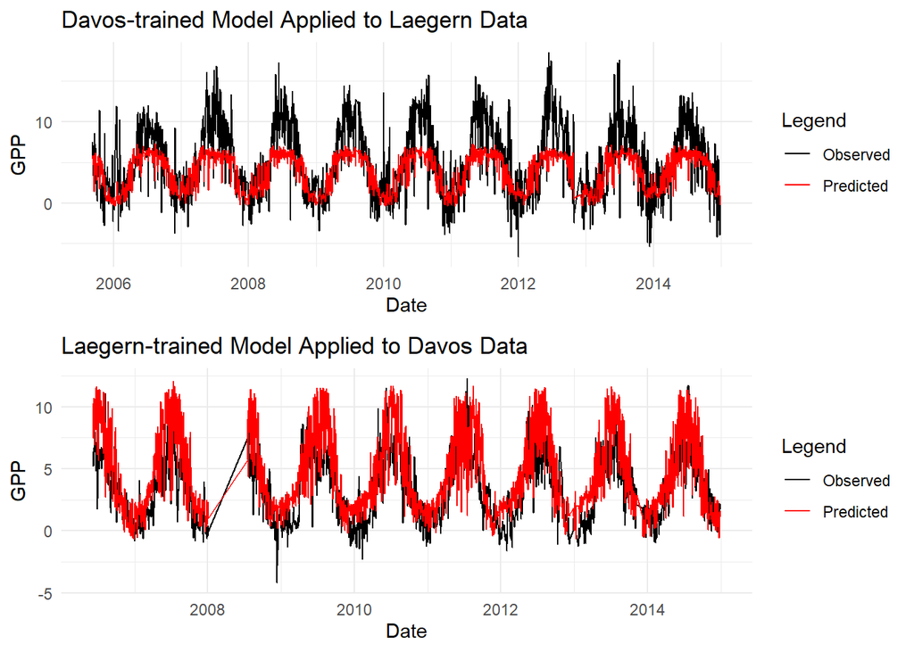

```r
# davos-trained model on laegern site
davos_laegern <- get_model_predictions(davos_only_model, laegern_fluxes)

# plot time series
plot_davos_laegern <- ggplot(
  data = davos_laegern,
  aes(x = Date)) +
  geom_line(aes(y = Observations, color = "Observed")) +
  geom_line(aes(y = Predictions, color = "Predicted")) +
  labs(
    title = "Davos-trained Model Applied to Laegern Data",
    x = "Date",
    y = "GPP",
    color = "Legend") +
  scale_color_manual(values = c("Observed" = "black", "Predicted" = "red")) +
  theme_minimal()



# laegern-trained model on davos site
laegern_davos <- get_model_predictions(laegern_only_model, davos_fluxes)

# plot time series
plot_laegern_laegern <- ggplot(
  data = laegern_davos,
  aes(x = Date)) +
  geom_line(aes(y = Observations, color = "Observed")) +
  geom_line(aes(y = Predictions, color = "Predicted")) +
  labs(
    title = "Laegern-trained Model Applied to Davos Data",
    x = "Date",
    y = "GPP",
    color = "Legend") +
  scale_color_manual(values = c("Observed" = "black", "Predicted" = "red")) +
  theme_minimal()



# present both plots
cowplot::plot_grid(plot_davos_laegern, plot_laegern_laegern, nrow = 2)
```

For further validation of this hypothesis, I compare the performance of both models on the Laegern test data. The Laegern-trained model should perform better while the Davos-trianed model should predict a GPP that is too low compared to observations.

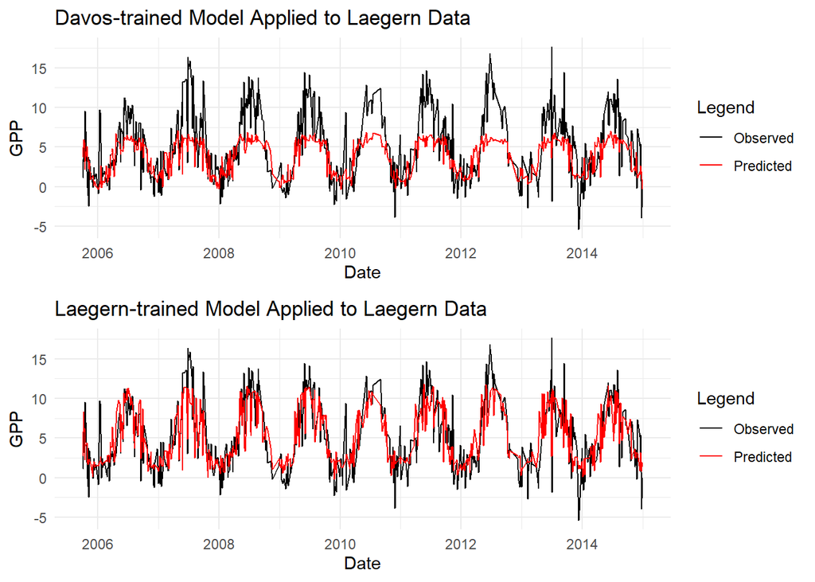

```r
# davos-trained model on laegern test data
davos_laegern <- get_model_predictions(davos_only_model, laegern_split$test)

# plot time series
plot_davos_laegern <- ggplot(
  data = davos_laegern, aes(x = Date)) +
  geom_line(aes(y = Observations, color = "Observed")) +
  geom_line(aes(y = Predictions, color = "Predicted")) +
  labs(
    title = "Davos-trained Model Applied to Laegern Data",
    x = "Date",
    y = "GPP",
    color = "Legend") +
  scale_color_manual(values = c("Observed" = "black", "Predicted" = "red")) +
  theme_minimal()



# laegern-trained model on laegern test data
laegern_laegern <- get_model_predictions(laegern_only_model, laegern_split$test)

# plot time series
plot_laegern_laegern <- ggplot(
  data = laegern_laegern, aes(x = Date)) +
  geom_line(aes(y = Observations, color = "Observed")) +
  geom_line(aes(y = Predictions, color = "Predicted")) +
  labs(
    title = "Laegern-trained Model Applied to Laegern Data",
    x = "Date",
    y = "GPP",
    color = "Legend") +
  scale_color_manual(values = c("Observed" = "black", "Predicted" = "red")) +
  theme_minimal()



# present both plots
cowplot::plot_grid(plot_davos_laegern, plot_laegern_laegern, nrow = 2)
```

## Learnings

**How does the model trained on both sites perform on the three test sets? Why is this the case?**

**When training and testing on both sites, is this a true ‘out-of-sample’ setup?**

- No, it is not a true out-of-sample setup. The model was already trained with data from the same site as it is tested on. Even though it has never encountered that exact data due to the data leakage-proof splitting, the data is likely very similar.

**What would you expect if your model was tested against data from a site in Spain?**

- Under the assumption that the climate on the site in Spain is mediterranian, I would expect the Laegern-trained model to perform best. Because the environmental conditions are more similar to Laegern than to Davos. The combined model is trained on a “mix” of these two environments but it is a “compromise” that is further from the Mediterranean conditions than a Laegern-only model.